# Benchmarks: vect2mat2vect

This notebook is all about benchmarking some R code used in this package.

Hardware / Software used:

- Intel i7-4600U
- Compilation flags for C/C++: `-O2 -Wall $(DEBUGFLAG) -mtune=core2` (R’s defaults)
- Windows Server 2012 R2
- R 3.3.2 + Intel MKL

# Libraries

```r
library(data.table)
library(microbenchmark)
library(Rcpp)
library(ggplot2)
```

```r
# Helper function to print data well in tables
print_well <- function(data, digits = 6) {

  # To milliseconds
  data <- data / 1000000

  # Sprintf helper
  sprintf_helper <- paste0("%.0", digits, "f")

  cat("| Min | 25% | 50% | 75% | Max | Mean |  \n| --: | --: | --: | --: | --: | --: |  \n| ", sprintf(sprintf_helper, min(data)), " | ", sprintf(sprintf_helper, quantile(data, probs = 0.25)), " | ", sprintf(sprintf_helper, median(data)), " | ", sprintf(sprintf_helper, quantile(data, probs = 0.75)), " | ", sprintf(sprintf_helper, max(data)), " | ", sprintf(sprintf_helper, mean(data)), " |  \n", sep = "")

  return(data)

}
# Test case function
# Arguments renamed to avoid recursive clash
test_case <- function(f, preds, labels) {
  cat("Test case: ", paste(do.call(f, list(preds = preds[1:50],
                                           labels = labels[1:5])), collapse = ", "), "  \n", sep = "")
}
```

# Benchmarking

For a 10-class vector of 1,000,000 observations:

- Vector A of length=(1000000 * 10)
- Vector B of length=(1000000) with 10 classes

```
A = [1:1, 1:2, 1:3, 1:4... 1:10, 2:1, 2:2, 2:3..., 1000000:8, 1000000:9, 1000000:10]
B = [3, 5, 9, 1, 4, 8, 6, ...]
```

Get the following Vector C:

```
C = [1:4, 2:6, 3:10, 4:2, 5:5, 6:9, 7:7, ...]
```

# Initialize data

```r
# How many digits for benchmarking in milliseconds
my_digits <- 6L
# How many runs for benchmarking?
my_runs <- 1000L
# How many observations?
my_obs <- 1000000L
# Generate random data
set.seed(11111)
data <- runif(my_obs * 10, 0, 1)
labels <- round(runif(my_obs, 0, 9), digits = 0)
# Background truth example
array(data[1:50], dim = c(10, 5))
```

```
           [,1]       [,2]       [,3]       [,4]       [,5]
 [1,] 0.5014483 0.57219649 0.70236924 0.06440384 0.78924978
 [2,] 0.9702328 0.34292525 0.50889166 0.65780657 0.72449914
 [3,] 0.7876004 0.09627503 0.20268701 0.19973930 0.00886554
 [4,] 0.9022259 0.74235690 0.90706612 0.24664551 0.57348710
 [5,] 0.8141778 0.42274539 0.05441064 0.25997440 0.73034459
 [6,] 0.7998922 0.98402494 0.09045308 0.14869691 0.42458612
 [7,] 0.1158690 0.89258437 0.85759800 0.21375685 0.07684022
 [8,] 0.7171363 0.59541565 0.94780036 0.20598170 0.53318628
 [9,] 0.1020639 0.80531234 0.16479666 0.02075780 0.28521238
[10,] 0.6856938 0.42102379 0.42536097 0.63880218 0.86408083
```

```r
labels[1:5]
```

```
[1] 5 1 1 7 8
```

```r
data[c(1 + labels[1], 11 + labels[2], 21 + labels[3], 31 + labels[4], 41 + labels[5])]
```

```
[1] 0.7998922 0.3429253 0.5088917 0.2059817 0.2852124
```

# Benchmarks

```r
# ===== BLOCK 1 =====
faster1 <- function(preds, labels) {
  data_len <- length(preds)
  label_len <- length(labels)
  len_div <- data_len / label_len
  dims <- c(len_div, label_len)
  label_long <- labels + 1
  mat_out <- cbind(label_long, 1:label_len)
  vec_out <- array(preds, dim = dims)[mat_out]
  return(vec_out)
}
test_case(faster1, preds = data, labels = labels)
```

Test case: 0.799892218317837, 0.342925252625719, 0.508891655597836, 0.205981696723029, 0.285212381277233

```r
data1 <- print_well(microbenchmark(faster1(data, labels), times = my_runs)$time, digits = my_digits)
```

| Min | 25% | 50% | 75% | Max | Mean |
| --- | --- | --- | --- | --- | --- |
| 64.477183 | 76.715004 | 82.423414 | 93.216622 | 227.850224 | 94.846972 |

```r
# ===== BLOCK 2 =====
faster2 <- function(preds, labels) {
  data_len <- length(preds)
  label_len <- length(labels)
  vec_out <- array(preds, dim = c(data_len / label_len, label_len))[cbind(labels + 1, 1:label_len)]
  return(vec_out)
}
test_case(faster2, preds = data, labels = labels)
```

Test case: 0.799892218317837, 0.342925252625719, 0.508891655597836, 0.205981696723029, 0.285212381277233

```r
data2 <- print_well(microbenchmark(faster2(data, labels), times = my_runs)$time, digits = my_digits)
```

| Min | 25% | 50% | 75% | Max | Mean |
| --- | --- | --- | --- | --- | --- |
| 65.549548 | 77.369408 | 78.821814 | 82.645033 | 165.423494 | 85.019410 |

```r
# ===== BLOCK 3 =====
faster3 <- function(preds, labels) {
  return(array(preds, dim = c(length(preds) / length(labels), length(labels)))[cbind(labels + 1, 1:length(labels))])
}
test_case(faster3, preds = data, labels = labels)
```

Test case: 0.799892218317837, 0.342925252625719, 0.508891655597836, 0.205981696723029, 0.285212381277233

```r
data3 <- print_well(microbenchmark(faster3(data, labels), times = my_runs)$time, digits = my_digits)
```

| Min | 25% | 50% | 75% | Max | Mean |
| --- | --- | --- | --- | --- | --- |
| 70.189490 | 77.282547 | 78.505350 | 82.392338 | 154.380158 | 82.095122 |

```r
# ===== BLOCK 4 =====
faster4 <- function(preds, labels) {
  return(array(preds, dim = c(length(preds) / length(labels), length(labels)))[matrix(c(labels + 1, 1:length(labels)), ncol = 2)])
}
test_case(faster4, preds = data, labels = labels)
```

Test case: 0.799892218317837, 0.342925252625719, 0.508891655597836, 0.205981696723029, 0.285212381277233

```r
data4 <- print_well(microbenchmark(faster4(data, labels), times = my_runs)$time, digits = my_digits)
```

| Min | 25% | 50% | 75% | Max | Mean |
| --- | --- | --- | --- | --- | --- |
| 84.698529 | 86.697380 | 88.392122 | 92.799232 | 172.820185 | 92.417136 |

```r
# ===== BLOCK 5 =====
faster5 <- function(preds, labels) {
  return(preds[((0:(length(labels) - 1)) * (length(preds) / length(labels))) + labels + 1])
}
test_case(faster5, preds = data, labels = labels)
```

Test case: 0.799892218317837, 0.342925252625719, 0.508891655597836, 0.205981696723029, 0.285212381277233

```r
data5 <- print_well(microbenchmark(faster5(data, labels), times = my_runs)$time, digits = my_digits)
```

| Min | 25% | 50% | 75% | Max | Mean |
| --- | --- | --- | --- | --- | --- |
| 23.506483 | 24.614390 | 25.012773 | 29.915200 | 111.046150 | 28.619188 |

```r
# ===== BLOCK 6 =====
cppFunction("NumericVector faster6(NumericVector preds, NumericVector labels) {
  int labels_size = labels.size();
  NumericVector selected(labels_size);
  selected = (preds.size() / labels_size) * seq(0, labels_size - 1);
  selected = selected + labels;
  NumericVector to_return(labels_size);
  to_return = preds[selected];
  return to_return;
}")
test_case(faster6, preds = data, labels = labels)
```

Test case: 0.799892218317837, 0.342925252625719, 0.508891655597836, 0.205981696723029, 0.285212381277233

```r
data6 <- print_well(microbenchmark(faster6(data, labels), times = my_runs)$time, digits = my_digits)
```

| Min | 25% | 50% | 75% | Max | Mean |
| --- | --- | --- | --- | --- | --- |
| 21.432080 | 22.046190 | 22.483536 | 29.204154 | 104.632112 | 26.034868 |

# Summary Results

```r
data_time <- data.table(rbindlist(list(data.frame(Time = data1, Bench = "faster1"),
                                       data.frame(Time = data2, Bench = "faster2"),
                                       data.frame(Time = data3, Bench = "faster3"),
                                       data.frame(Time = data4, Bench = "faster4"),
                                       data.frame(Time = data5, Bench = "faster5"),
                                       data.frame(Time = data6, Bench = "faster6"))))
data_time <- data_time[, t_mean := mean(Time), by = Bench]
data_time <- data_time[, t_median := median(Time), by = Bench]
data_time$Benchs <- data_time$Bench
levels(data_time$Benchs) <- paste0("faster", 1:6, "= [", sprintf(paste0("%.0", my_digits, "f"), data_time[, list(min(Time)), by = Bench]$V1), ", ", sprintf(paste0("%.0", my_digits, "f"), data_time[, list(max(Time)), by = Bench]$V1), "], mean=", sprintf(paste0("%.0", my_digits, "f"), data_time[, list(mean(Time)), by = Bench]$V1), ", median=", sprintf(paste0("%.0", my_digits, "f"), data_time[, list(median(Time)), by = Bench]$V1))
my_time <- data_time[, list(min(Time), quantile(Time, probs = 0.25), median(Time), quantile(Time, probs = 0.75), max(Time), mean(Time)), by = Bench]
colnames(my_time) <- c("Function", "Min", "25%", "50%", "75%", "Max", "Mean")
my_time <- my_time[order(Mean, decreasing = FALSE), ]
print(my_time, digits = 6)
```

| Function | Min | 25% | 50% | 75% | Max | Mean |
| --- | --- | --- | --- | --- | --- | --- |
| faster6 | 21.43208 | 22.04619 | 22.48354 | 29.20415 | 104.6321 | 26.03487 |
| faster5 | 23.50648 | 24.61439 | 25.01277 | 29.91520 | 111.0461 | 28.61919 |
| faster3 | 70.18949 | 77.28255 | 78.50535 | 82.39234 | 154.3802 | 82.09512 |
| faster2 | 65.54955 | 77.36941 | 78.82181 | 82.64503 | 165.4235 | 85.01941 |
| faster4 | 84.69853 | 86.69738 | 88.39212 | 92.79923 | 172.8202 | 92.41714 |
| faster1 | 64.47718 | 76.71500 | 82.42341 | 93.21662 | 227.8502 | 94.84697 |

# Plot Results

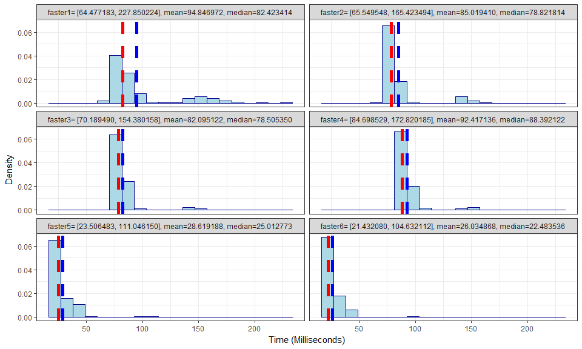

```r
ggplot(data = data_time, aes(x = Time)) + geom_histogram(aes(y = ..density..), bins = 20, color = "darkblue", fill = "lightblue") + facet_wrap(~ Benchs, ncol = 2) + geom_vline(aes(xintercept = t_mean), color = "blue", linetype = "dashed", size = 2) + geom_vline(aes(xintercept = t_median), color = "red", linetype = "dashed", size = 2) + labs(x = "Time (Milliseconds)", y = "Density") + theme_bw()
```

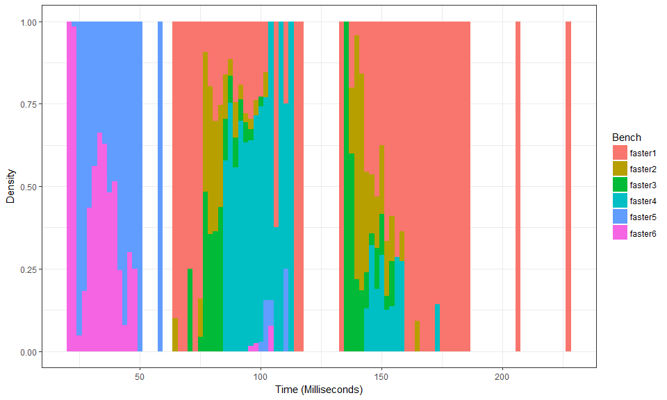

```r
ggplot(data = data_time[, .(Time, Bench)], aes(x = Time, y = ..count.., fill = Bench)) + geom_histogram(aes(y = ..density..), bins = 100, position = "fill") + labs(x = "Time (Milliseconds)", y = "Density") + theme_bw()
```

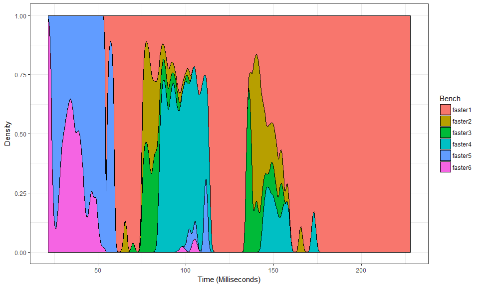

```r
ggplot(data = data_time, aes(x = Time, y = ..count.., fill = Bench)) + geom_density(position = "fill") + labs(x = "Time (Milliseconds)", y = "Density") + theme_bw()
```

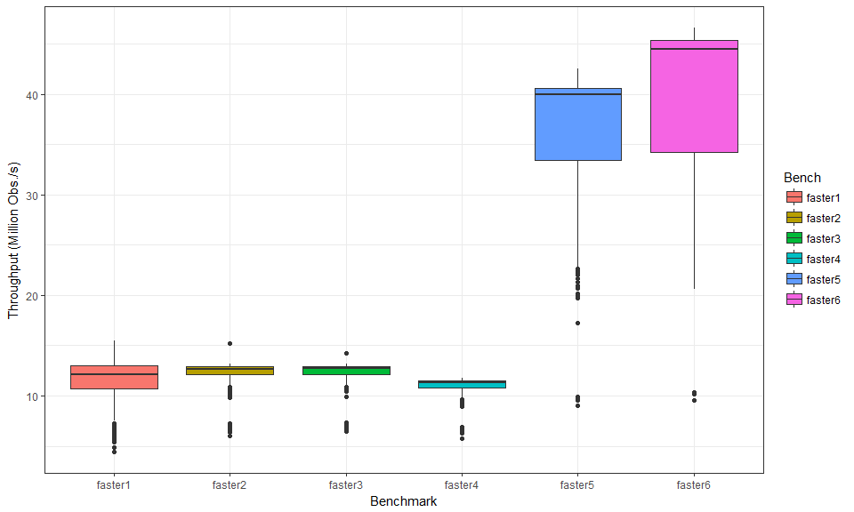

```r
data_time$MilObs <- (1000 / data_time$Time) * my_obs / 1000000
ggplot(data_time[, .(Bench, MilObs)], aes(x = Bench, y = MilObs, fill = Bench)) + geom_boxplot() + labs(x = "Benchmark", y = "Throughput (Million Obs./s)") + theme_bw()
```

# Scaling Benchmarks

```r
Benchmarker <- function(f, size, runs, digits, name) {

  data_runs <- list()

  for (i in 1:length(size)) {
    set.seed(11111)
    data <- runif(size[i] * 10, 0, 1)
    labels <- round(runif(size[i], 0, 9), digits = 0)
    cat("  \n  \n## ", name, " run: ",format(size[i], big.mark = ",", scientific = FALSE), " samples (", format(runs[i], big.mark = ",", scientific = FALSE), " times)  \n  \n", sep = "")
    test_case(f, preds = data, labels = labels)
    cat("  \n")
    data_runs[[i]] <- print_well(microbenchmark(f(data, labels), times = runs[i])$time, digits = digits)
    data_runs[[i]] <- data.table(Bench = as.factor(paste0("[", i, "] ", format(size[i], big.mark = ",", scientific = FALSE))), Function = as.factor(name), Time = data_runs[[i]])
    gc(verbose = FALSE)
  }

  return(data_runs)

}
bench_size <- c(100, 1000, 10000, 100000, 1000000, 10000000)
bench_runs <- c(50000, 10000, 5000, 1000, 500, 100)
```

```r
run1 <- Benchmarker(faster5, bench_size, bench_runs, my_digits, "Pure R")
```

## Pure R run: 100 samples (50,000 times)

Test case: 0.902225864585489, 0.342925252625719, 0.94780036341399, 0.259974401211366, 0.533186275744811

| Min | 25% | 50% | 75% | Max | Mean |
| --- | --- | --- | --- | --- | --- |
| 0.004561 | 0.004942 | 0.005322 | 0.006082 | 9.497323 | 0.006711 |

## Pure R run: 1,000 samples (10,000 times)

Test case: 0.902225864585489, 0.572196492459625, 0.054410636657849, 0.657806565286592, 0.72449914435856

| Min | 25% | 50% | 75% | Max | Mean |
| --- | --- | --- | --- | --- | --- |
| 0.014825 | 0.017106 | 0.020528 | 0.022808 | 5.301000 | 0.021887 |

## Pure R run: 10,000 samples (5,000 times)

Test case: 0.102063933620229, 0.805312335956842, 0.508891655597836, 0.199739297153428, 0.730344592127949

| Min | 25% | 50% | 75% | Max | Mean |
| --- | --- | --- | --- | --- | --- |
| 0.132287 | 0.134568 | 0.136849 | 0.158897 | 3.291980 | 0.159926 |

## Pure R run: 100,000 samples (1,000 times)

Test case: 0.902225864585489, 0.98402493679896, 0.857597996480763, 0.24664551159367, 0.573487095767632

| Min | 25% | 50% | 75% | Max | Mean |
| --- | --- | --- | --- | --- | --- |
| 1.751288 | 1.882719 | 1.972336 | 2.411014 | 14.073783 | 2.265706 |

## Pure R run: 1,000,000 samples (500 times)

Test case: 0.799892218317837, 0.342925252625719, 0.508891655597836, 0.205981696723029, 0.285212381277233

| Min | 25% | 50% | 75% | Max | Mean |
| --- | --- | --- | --- | --- | --- |
| 19.287351 | 19.994405 | 21.950775 | 25.025793 | 98.634323 | 23.533861 |

## Pure R run: 10,000,000 samples (100 times)

Test case: 0.71713633579202, 0.422745394520462, 0.508891655597836, 0.638802175875753, 0.72449914435856

| Min | 25% | 50% | 75% | Max | Mean |
| --- | --- | --- | --- | --- | --- |
| 236.005666 | 244.768375 | 256.760342 | 301.175933 | 404.297288 | 275.188392 |

```r
run2 <- Benchmarker(faster6, bench_size, bench_runs, my_digits, "Rcpp")
```

## Rcpp run: 100 samples (50,000 times)

Test case: 0.902225864585489, 0.342925252625719, 0.94780036341399, 0.259974401211366, 0.533186275744811

| Min | 25% | 50% | 75% | Max | Mean |
| --- | --- | --- | --- | --- | --- |
| 0.001520 | 0.002281 | 0.002661 | 0.002662 | 14.984590 | 0.003294 |

## Rcpp run: 1,000 samples (10,000 times)

Test case: 0.902225864585489, 0.572196492459625, 0.054410636657849, 0.657806565286592, 0.72449914435856

| Min | 25% | 50% | 75% | Max | Mean |
| --- | --- | --- | --- | --- | --- |
| 0.008744 | 0.011024 | 0.015206 | 0.016727 | 0.138750 | 0.015316 |

## Rcpp run: 10,000 samples (5,000 times)

Test case: 0.102063933620229, 0.805312335956842, 0.508891655597836, 0.199739297153428, 0.730344592127949

| Min | 25% | 50% | 75% | Max | Mean |
| --- | --- | --- | --- | --- | --- |
| 0.090472 | 0.093894 | 0.101496 | 0.119743 | 3.596848 | 0.113891 |

## Rcpp run: 100,000 samples (1,000 times)

Test case: 0.902225864585489, 0.98402493679896, 0.857597996480763, 0.24664551159367, 0.573487095767632

| Min | 25% | 50% | 75% | Max | Mean |
| --- | --- | --- | --- | --- | --- |
| 1.366970 | 1.450981 | 1.492605 | 1.668038 | 10.348068 | 1.670666 |

## Rcpp run: 1,000,000 samples (500 times)

Test case: 0.799892218317837, 0.342925252625719, 0.508891655597836, 0.205981696723029, 0.285212381277233

| Min | 25% | 50% | 75% | Max | Mean |
| --- | --- | --- | --- | --- | --- |
| 16.141344 | 16.561489 | 17.450723 | 19.082648 | 86.748224 | 18.538569 |

## Rcpp run: 10,000,000 samples (100 times)

Test case: 0.71713633579202, 0.422745394520462, 0.508891655597836, 0.638802175875753, 0.72449914435856

| Min | 25% | 50% | 75% | Max | Mean |
| --- | --- | --- | --- | --- | --- |
| 208.121154 | 219.600317 | 232.588241 | 256.038464 | 366.712081 | 240.559222 |

# Scaling Results

```r
run1_all <- rbindlist(run1)
run2_all <- rbindlist(run2)
run_all <- rbind(run1_all, run2_all)
run_all$Repeats <- rep(inverse.rle(list(lengths = bench_runs, values = bench_size)), 2)
run_all$MilObs <- (1000 / run_all$Time) * run_all$Repeats / 1000000
run_time <- run_all[, list(quantile(Time, probs = 0.05), median(Time), quantile(Time, probs = 0.95), mean(Time)), by = list(Function, Bench)]
colnames(run_time) <- c("Function", "Benchmark", "5%", "50%", "95%", "Mean")
run_time$`Mil.Obs/s` <- (1000 / run_time$Mean) * bench_size / 1000000
run_time$`5%` <- format(run_time$`5%`, digits = 6, scientific = FALSE)
run_time$`50%` <- format(run_time$`50%`, digits = 6, scientific = FALSE)
run_time$`95%` <- format(run_time$`95%`, digits = 6, scientific = FALSE)
run_time$Mean <- format(run_time$Mean, digits = 6, scientific = FALSE)
run_time$`Mil.Obs/s` <- format(run_time$`Mil.Obs/s`, digits = 6, scientific = FALSE)
print(run_time[1:(nrow(run_time) / 2)])
```

| Function | Benchmark | 5% | 50% | 95% | Mean | Mil.Obs/s |
| --- | --- | --- | --- | --- | --- | --- |
| Pure R | [1] 100 | 0.004562 | 0.005322 | 0.0102640 | 0.00671105 | 14.9008 |
| Pure R | [2] 1,000 | 0.015585 | 0.020528 | 0.0319509 | 0.02188728 | 45.6886 |
| Pure R | [3] 10,000 | 0.133428 | 0.136849 | 0.2497500 | 0.15992610 | 62.5289 |
| Pure R | [4] 100,000 | 1.803728 | 1.972336 | 2.7429101 | 2.26570621 | 44.1363 |
| Pure R | [5] 1,000,000 | 19.625083 | 21.950775 | 29.6754853 | 23.53386112 | 42.4920 |
| Pure R | [6] 10,000,000 | 241.693948 | 256.760342 | 345.0354973 | 275.18839190 | 36.3387 |

```r
print(run_time[(nrow(run_time) / 2 + 1):nrow(run_time)])
```

| Function | Benchmark | 5% | 50% | 95% | Mean | Mil.Obs/s |
| --- | --- | --- | --- | --- | --- | --- |
| Rcpp | [1] 100 | 0.001901 | 0.002661 | 0.0041820 | 0.00329447 | 30.3539 |
| Rcpp | [2] 1,000 | 0.010264 | 0.015206 | 0.0235690 | 0.01531583 | 65.2919 |
| Rcpp | [3] 10,000 | 0.092373 | 0.101496 | 0.1668800 | 0.11389099 | 87.8033 |
| Rcpp | [4] 100,000 | 1.405344 | 1.492605 | 2.2055691 | 1.67066609 | 59.8564 |
| Rcpp | [5] 1,000,000 | 16.303833 | 17.450723 | 22.7755572 | 18.53856875 | 53.9416 |
| Rcpp | [6] 10,000,000 | 212.374460 | 232.588241 | 291.6289452 | 240.55922233 | 41.5698 |

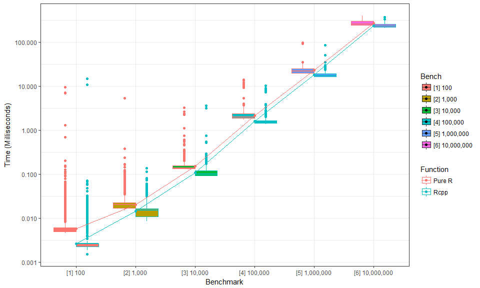

```r
ggplot(run_all, aes(x = Bench, y = Time, color = Function, fill = Bench)) + geom_boxplot() + scale_y_log10(labels = scales::comma, breaks = c(0.001, 0.01, 0.1, 1, 10, 100, 1000, 10000, 100000, 1000000)) + stat_summary(fun.y = mean, geom = "line", aes(group = Function)) + stat_summary(fun.y = mean, geom = "point", aes(group = Function)) + labs(x = "Benchmark", y = "Time (Milliseconds)") + theme_bw()
```

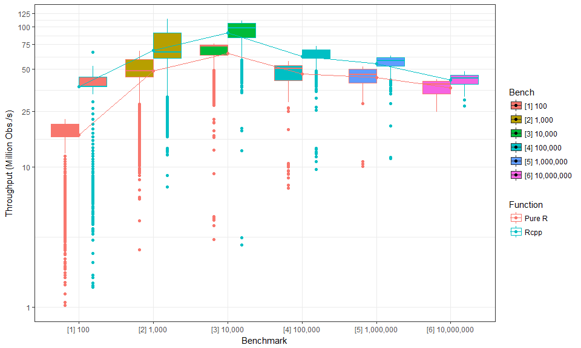

```r
ggplot(run_all, aes(x = Bench, y = MilObs, color = Function, fill = Bench)) + geom_boxplot() + scale_y_log10(labels = scales::comma, breaks = c(1, 10, 25, 50, 75, 100, 125, 150, 175, 200), limits = c(1, NA)) + stat_summary(fun.y = mean, geom = "line", aes(group = Function)) + stat_summary(fun.y = mean, geom = "point", aes(group = Function)) + labs(x = "Benchmark", y = "Throughput (Million Obs./s)") + theme_bw()
```

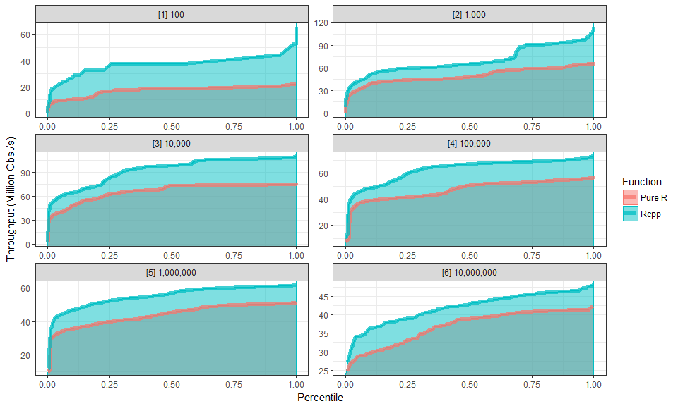

```r
ggplot(data = run_all, aes(x = MilObs, color = Function, fill = Function, group = Function)) + coord_flip() + stat_ecdf(aes(ymin = ..y.., ymax = 1), alpha = 0.5, geom = "ribbon") + stat_ecdf(geom = "line", size = 2, alpha = 0.75, pad = FALSE) + labs(x = "Throughput (Million Obs./s)", y = "Percentile") + facet_wrap(~ Bench, dir = "h", ncol = 2, scales = "free") + theme_bw()
```